# Predict Correct Use of Dumbbells

Frank Jung

21 October 2015

## Overview

This report describes the algorithm used to predict how well people perform the exercise of lifting a dumbbell. This is a classification problem where predictors are used to determine one of five outcomes. This report will:

- describe the choices made in choosing a model
- describe how the model was built
- cross validate the model
- estimate the out-of-sample error rate

Links to data and further information of the original research can be found in the appendices.

### Background

Using devices such as [Jawbone Up](https://jawbone.com/up), [Nike FuelBand](http://www.nike.com/), and [Fitbit](https://www.fitbit.com) it is now possible to collect a large amount of data about personal activity relatively inexpensively. These type of devices are part of the quantified self movement, a group of enthusiasts who take measurements about themselves regularly to improve their health, to find patterns in their behavior, or because they are tech geeks. One thing that people regularly do is quantify how much of a particular activity they do, but they rarely quantify how well they do it.

### Goal

Here we wish to predict the manner in which people do an exercise from data collected from accelerometers on the belt, forearm, arm, and dumbbell of 6 participants. They were asked to perform dumbbell lifts correctly and incorrectly in 5 different ways:

Classes of exercise activity

| Classe | Description |
| --- | --- |
| A | exactly according to the specification |
| B | throwing the elbows to the front |
| C | lifting the dumbbell only halfway |
| D | lowering the dumbbell only halfway |
| E | and throwing the hips to the front |

The prediction algorithm will determine which classification an exercise falls into.

## Exploratory Analysis

The `classe` field is a categorical outcome, which we will treat as a factor.

The data contains a large number (160) of columns. However, many of these columns contain little or no information or contain an Excel `#DIV/0!` conversion error. Consequently, we will exclude from the prediction formula all columns with a 95% or higher of missing data.

A number of columns will also be excluded since they do not provide value to prediction. They are:

Additional columns to ignore

| Column | Reason |
| --- | --- |
| `X` | Row index not related to a measurement |
| `*_window`, `*_timestamp*` | measurements were made in time segments with overlap so they can be treated as discrete and not time dependent |
| `user_name` | who performed the action is not relevant as all were supervised to ensure consistent actions |

## Training

### Choice of Prediction Algorithm

A good performing prediction algorithm for classification problems is [Random Forest](https://en.wikipedia.org/wiki/Random_forest). It is resilient to outliers but is affected by multi-collinearity. This will be tested later.

### Data Partitioning

The training data was partitioned into two:

- training (70%) - used to train model
- testing (30%) - used for cross-validation, and estimation of the error rate

```r
# split into train (70%) and test (30%) on outcome (classe)
set.seed(033)
rawindex <- createDataPartition(raw$classe, p = 0.7, list = FALSE)
training <- raw[rawindex,]
testing <- raw[-rawindex,]
```

### Training Formula

The model prediction formula is composed of all fields, **except**:

- columns that are more than 95% empty
- non-predictive columns identified in Table: Additional columns to ignore

Applying these conditions gives the prediction formula:

```r
# ignore columns that are more than 95% empty (i.e. NA):
nasPerc <- as.integer(0.95 * nrow(training))
nas <- sort(apply(training, 2, function(x) length(which(is.na(x)))), decreasing = TRUE)
badNames <- sort(names(nas[nas >= nasPerc]))
goodNames <- setdiff(names(training), badNames)

# exclude columns that do not aid in prediction (or are an outcome)
trainNames <-
    grep(
      paste("classe", "window", "user_name", "X", "_timestamp", sep = "|"),
      goodNames, value = TRUE, invert = TRUE
    )

# use these column names to generate training formula
trainFormula <- as.formula(paste("classe ~ ", paste(trainNames, collapse = "+")))
print(trainFormula)
```

```
## classe ~ roll_belt + pitch_belt + yaw_belt + total_accel_belt +
##     gyros_belt_x + gyros_belt_y + gyros_belt_z + accel_belt_x +
##     accel_belt_y + accel_belt_z + magnet_belt_x + magnet_belt_y +
##     magnet_belt_z + roll_arm + pitch_arm + yaw_arm + total_accel_arm +
##     gyros_arm_x + gyros_arm_y + gyros_arm_z + accel_arm_x + accel_arm_y +
##     accel_arm_z + magnet_arm_x + magnet_arm_y + magnet_arm_z +
##     roll_dumbbell + pitch_dumbbell + yaw_dumbbell + total_accel_dumbbell +
##     gyros_dumbbell_x + gyros_dumbbell_y + gyros_dumbbell_z +
##     accel_dumbbell_x + accel_dumbbell_y + accel_dumbbell_z +
##     magnet_dumbbell_x + magnet_dumbbell_y + magnet_dumbbell_z +
##     roll_forearm + pitch_forearm + yaw_forearm + total_accel_forearm +
##     gyros_forearm_x + gyros_forearm_y + gyros_forearm_z + accel_forearm_x +
##     accel_forearm_y + accel_forearm_z + magnet_forearm_x + magnet_forearm_y +
##     magnet_forearm_z
```

This will appear below in training as the variable `trainFormula`.

### Check Multi-Collinearity

No collinear variables were identified. The predictors used in the formula, were tested using rfUtilities:

```r
multi.collinear(dplyr::select(training, one_of(trainNames)))
```

```
## [1] " NO MULTICOLINEAR VARIABLES IDENTIFIED"
```

### Training Model

For training we will use a cross-validated Random Forest using the [caret](http://topepo.github.io/caret/index.html) package. The cross-validation used here is a simple k-fold. Where k is set to 5.

```r
model <- train(trainFormula, data = training, method = "rf",
               trControl = trainControl(method = "cv", number = 5))
```

[output not shown]

Where `mtry` is the number of randomly selected predictors.

### Variable Importance

A plot of [variable importance](https://en.wikipedia.org/wiki/Random_forest#Variable_importance) scaled from 0 (low importance) to 100 (high importance):

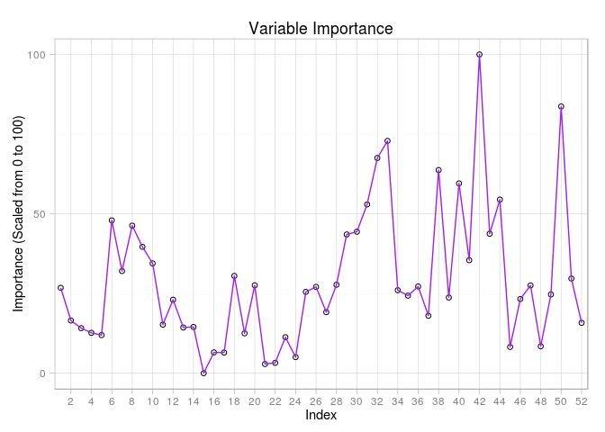

The full list by scaled variable importance:

Variable Importance

| Index | Variable | Importance |
| --- | --- | --- |
| 42 | roll_belt | 100.00 |
| 50 | yaw_belt | 83.68 |
| 33 | magnet_dumbbell_z | 72.88 |
| 32 | magnet_dumbbell_y | 67.51 |
| 38 | pitch_belt | 63.73 |
| 40 | pitch_forearm | 59.54 |
| 44 | roll_forearm | 54.46 |
| 31 | magnet_dumbbell_x | 52.94 |
| 6 | accel_belt_z | 47.95 |
| 8 | accel_dumbbell_y | 46.29 |
| 30 | magnet_belt_z | 44.38 |
| 43 | roll_dumbbell | 43.75 |
| 29 | magnet_belt_y | 43.52 |
| 9 | accel_dumbbell_z | 39.64 |
| 41 | roll_arm | 35.45 |
| 10 | accel_forearm_x | 34.44 |
| 7 | accel_dumbbell_x | 32.04 |
| 18 | gyros_belt_z | 30.52 |
| 51 | yaw_dumbbell | 29.70 |
| 28 | magnet_belt_x | 27.74 |
| 20 | gyros_dumbbell_y | 27.57 |
| 47 | total_accel_dumbbell | 27.53 |
| 36 | magnet_forearm_z | 27.20 |
| 26 | magnet_arm_y | 27.08 |
| 1 | accel_arm_x | 26.79 |
| 34 | magnet_forearm_x | 26.03 |
| 25 | magnet_arm_x | 25.51 |
| 49 | yaw_arm | 24.71 |
| 35 | magnet_forearm_y | 24.32 |
| 39 | pitch_dumbbell | 23.75 |
| 46 | total_accel_belt | 23.27 |
| 12 | accel_forearm_z | 23.05 |
| 27 | magnet_arm_z | 19.14 |
| 37 | pitch_arm | 18.02 |
| 2 | accel_arm_y | 16.53 |
| 52 | yaw_forearm | 15.80 |
| 11 | accel_forearm_y | 15.22 |
| 14 | gyros_arm_y | 14.51 |
| 13 | gyros_arm_x | 14.33 |
| 3 | accel_arm_z | 14.12 |
| 4 | accel_belt_x | 12.66 |
| 19 | gyros_dumbbell_x | 12.51 |
| 5 | accel_belt_y | 11.95 |
| 23 | gyros_forearm_y | 11.29 |
| 48 | total_accel_forearm | 8.44 |
| 45 | total_accel_arm | 8.23 |
| 16 | gyros_belt_x | 6.52 |
| 17 | gyros_belt_y | 6.47 |
| 24 | gyros_forearm_z | 5.04 |
| 22 | gyros_forearm_x | 3.25 |
| 21 | gyros_dumbbell_z | 2.87 |
| 15 | gyros_arm_z | 0.00 |

## Testing

The model was next cross-validated against the reserved test data:

```r
# cross-validate
testPredict <- predict(model, newdata = testing)
```

### Estimation of Error Rate

Since this is categorical data, estimate using an accuracy measure:

```r
# estimate error (since this is categorical data we are estimating accuracy)
# page 37 (james2013introduction)
estimated <- sum(testPredict != testing$classe) / length(testing$classe)
```

So, against the independent testing dataset, the estimated error rate for this model is **0.969%**. Note that this is a more pessimistic estimate than the OOB estimated of error rate.

## Predictions

The model was then used to predict `classe` outcomes for a validation data set:

```r
validation <- read.csv("data/pml-testing.csv", header = TRUE,
                       na.strings = c("NA", "#DIV/0!"), stringsAsFactors = FALSE)

predictions <- predict(model, newdata = validation)
results <- data.frame(Classe = as.character(predictions))
rownames(results) <- 1:length(predictions)
kable(t(results), align = "c", caption = "Model Predictions for Validation Data")
```

Model Predictions for Validation Data

|  | 1 | 2 | 3 | 4 | 5 | 6 | 7 | 8 | 9 | 10 | 11 | 12 | 13 | 14 | 15 | 16 | 17 | 18 | 19 | 20 |
| --- | --- | --- | --- | --- | --- | --- | --- | --- | --- | --- | --- | --- | --- | --- | --- | --- | --- | --- | --- | --- |
| Classe | B | A | B | A | A | E | D | B | A | A | B | C | B | A | E | E | A | B | B | B |

## Appendices

### References

- Velloso, E.; Bulling, A.; Gellersen, H.; Ugulino, W.; Fuks, H. [Qualitative Activity Recognition of Weight Lifting Exercises](http://groupware.les.inf.puc-rio.br/work.jsf?p1=11201). Proceedings of 4th International Conference in Cooperation with SIGCHI (Augmented Human ’13) . Stuttgart, Germany: ACM SIGCHI, 2013. ([PDF](http://groupware.les.inf.puc-rio.br/public/papers/2013.Velloso.QAR-WLE.pdf))
- Book (hastie2009elements) Hastie, T.; Tibshirani, R. & Friedman, J. The Elements of Statistical Learning: Data Mining, Inference, and Prediction, Second Edition Springer, 2009
- Book (james2013introduction) James, G.; Witten, D.; Hastie, T. & Tibshirani, R. An Introduction to Statistical Learning: with Applications in R Springer New York, 2013

### Data

Data for this project was sourced from:

- Training data, https://d396qusza40orc.cloudfront.net/predmachlearn/pml-training.csv
- Validation data, https://d396qusza40orc.cloudfront.net/predmachlearn/pml-testing.csv

### Source

The source code and model data for this report are available from GitHub, https://github.com/frankjungdss/predmachlearn-033.

| Name | Description |
| --- | --- |
| getdata.R | download raw CSV data from remote sources |
| model-rf-cv.R | full script to train and test cross-validate random forest model |
| pred-rf-cv.R | prepare predictions for submission |